# practice-3_ujwal_joshi

### Intro to Matplotlib

Matplotlib is a comprehensive library for creating static, animated, and interactive visualizations in Python. It is used along with NumPy to provide an environment that is an effective open source alternative to MatLab. Thus, this may feel very familiar to you if you've ever used MatLab. Please note that Matplotlib is not the only tool for creating data visualization in Python. Other common libraries include [seaborn](https://seaborn.pydata.org/), [plotly](https://plotly.com/), and even [pandas](https://pandas.pydata.org/docs/user_guide/visualization.html) has some built in functions for quick plotting. This lab will mainly focus on Matplotlib, but I highly recommend checking out seaborn as well, since it can make some type of plots much easier to create. The good news is that seaborn is built on top of Matplotlib, so it will be very easy to pick up after going through this lab. However, you're free to use any of the plotting tools mentioned above throughout the course. Just as there were many ways to solve a problem in pandas, there are many ways to visualize our data.

Let's begin by importing matplotlib and learning how to create some beautiful graphs. If for some reason you don't have matplotlib installed, you will first have to go to your terminal (or Anaconda Prompt if on Windows) and enter the following:

`conda install matplotlib`

Make sure you've already installed [Anaconda](https://www.anaconda.com/)

```python
import numpy as np
import pandas as pd
import matplotlib.pyplot as plt
```

The cell below is optional. It just makes our figure sizes 15 x 5 and adds a darkgrid background by default. Feel free to experiment with these values if you'd like, but you'll have to restart the kernel and run all to see any changes.

```python
import seaborn as sns
from matplotlib import rcParams
rcParams['figure.figsize'] = 15, 5
sns.set_style('darkgrid')
```

### Plotting Numpy Arrays

Let's begin by creating some numpy arrays and plotting them. We can create a simple x, y graph using `plt.plot(x, y)`. We can then display this by calling `plt.show()`.

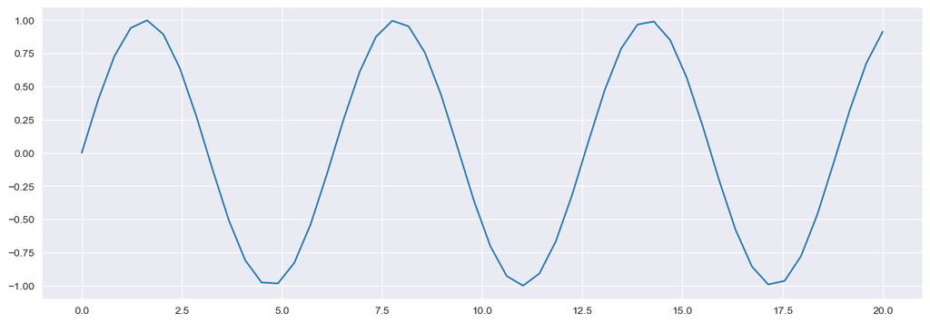

```python
x = np.linspace(0, 20)
y = np.sin(x)
plt.plot(x, y)
plt.show()
```

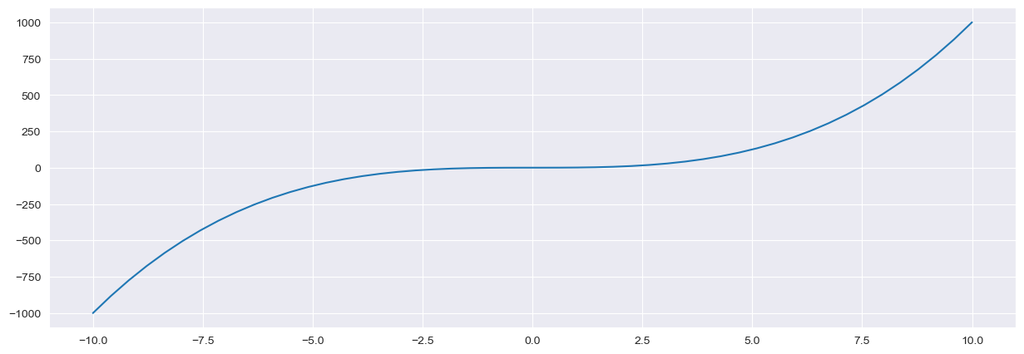

```python
# Modified Work
x1 = np.linspace(-10, 10)
y1 = np.power(x1, 3)
plt.plot(x1, y1)
plt.show()
```

It's would also be nice to add titles and axis labels to our graphs. We can accomplish this using `plt.title()` and `plt.x/ylabel()`.

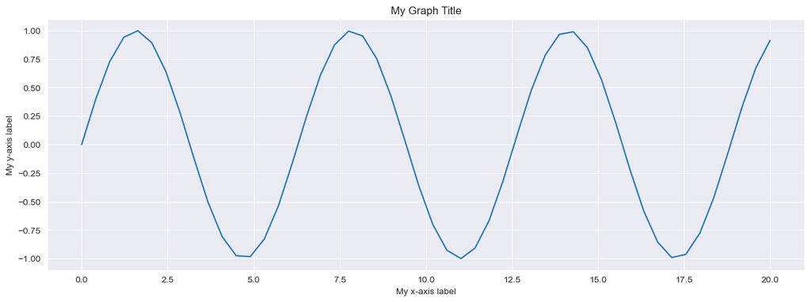

```python
plt.plot(x, y)
plt.title('My Graph Title')
plt.xlabel('My x-axis label')
plt.ylabel('My y-axis label')
plt.show()
```

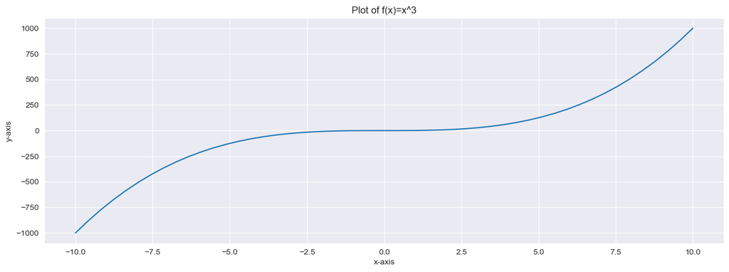

```python
# Modified Work
plt.plot(x1, y1)
plt.title('Plot of f(x)=x^3')
plt.xlabel('x-axis')
plt.ylabel('y-axis')
plt.show()
```

*Note: Make sure to add any titles/labels and such before calling plt.show(). Otherwise they will not show up.*

We'll sometimes like to plot more than one function together, which can be done by calling `plt.plot()` a second time in the same cell. However, make sure to add an additional **label** parameter when doing this to give each plot/function a unique label name. That way we can then call `plt.legend()`, which will automatically add a legend for us and let us know which plot is which.

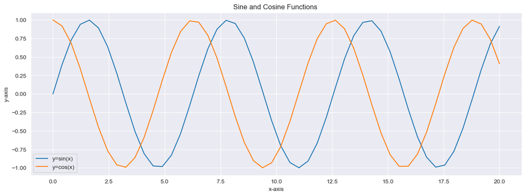

```python
plt.plot(x, np.sin(x), label='y=sin(x)')
plt.plot(x, np.cos(x), label='y=cos(x)')
plt.title('Sine and Cosine Functions ')
plt.xlabel("x-axis")
plt.ylabel("y-axis")
# Assigns a color to each plot along with it's corresponding label name to display in a legend.
plt.legend()
plt.show()
```

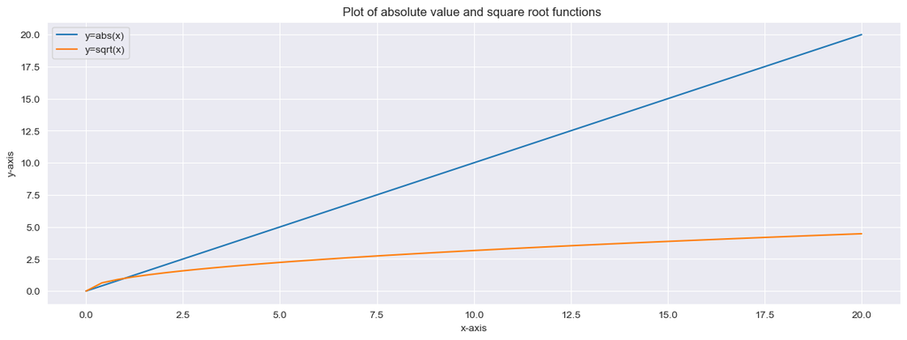

```python
# Modified Work
plt.plot(x, np.abs(x), label='y=abs(x)')
plt.plot(x, np.sqrt(x), label='y=sqrt(x)')

plt.title('Plot of absolute value and square root functions ')
plt.xlabel("x-axis")
plt.ylabel("y-axis")

plt.legend()
plt.show()
```

### Subplots

What if we instead wanted to plot sin(x) and cos(x) as separate plots, but side by side? This is where `subplots(nrows, ncols)` comes in handy. `subplots(nrows, ncols)` will return to us a figure object and a set of axes. To better understand subplots, think of a figure object as a large canvas where we can place a set of axes on. These set of axes are where we will plot our graphs on. Previously, we only had one single axis in our figure, and we were plotting 1 or many functions on that single axis. However, figures can have many axes, which we'll demonstrate using `subplots(nrows, ncols)`. For example, in the code below we tell `subplots(nrows, ncols)` that we would like a figure object with 1 row and 2 columns (essentially an array with 2 elements, where each element is an axis that we can plot on). Since axes can be thought of as an array holding the figure axes, we can index it to specify what we'd like to plot in each one.

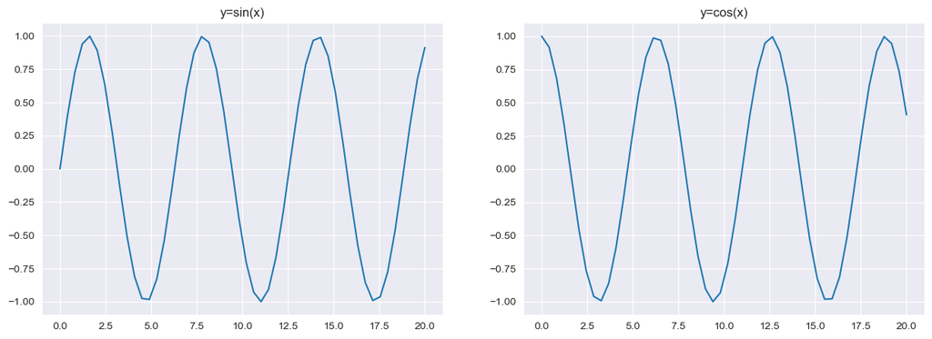

```python
# one figure object with 1x2=2 axes
fig, axes = plt.subplots(nrows=1, ncols=2)

# plotting sin(x) in axes[0]. left image, or 1st element/axis in the axes array.
axes[0].plot(x, np.sin(x))
# setting the title of axes[0] to be y=sin(x)
axes[0].set_title('y=sin(x)')

# plotting cos(x) in axes[1]. right image, or 2nd element/axis in the axes array.
axes[1].plot(x, np.cos(x))
# setting the title of axes[1] to be y=cos(x)
axes[1].set_title('y=cos(x)')

plt.show()
```

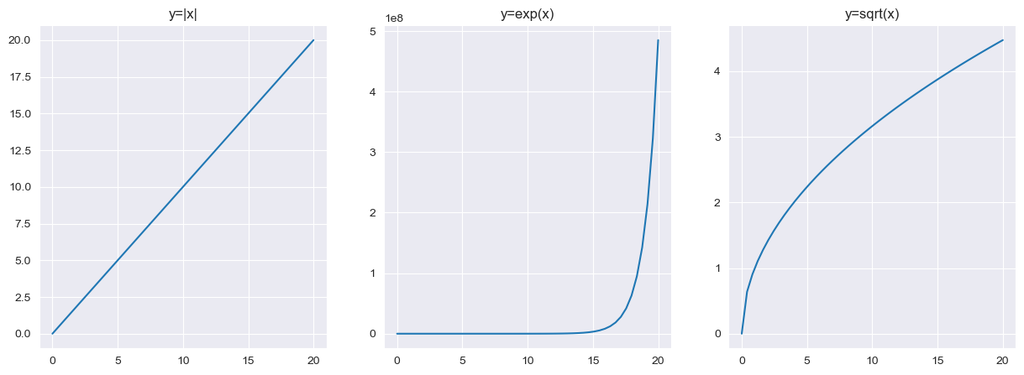

```python
# Modified Work
fig, axes = plt.subplots(nrows=1, ncols=3)

axes[0].plot(x, np.abs(x))
axes[0].set_title('y=|x|')

axes[1].plot(x, np.exp(x))
axes[1].set_title('y=exp(x)')

axes[2].plot(x, np.sqrt(x))
axes[2].set_title('y=sqrt(x)')

plt.show()
```

Try to see if you can now make a figure object with 2 rows and 2 columns, and plot something on all 4 axes. This will work exactly the same as above, except that we now index our axes as a 2d array.

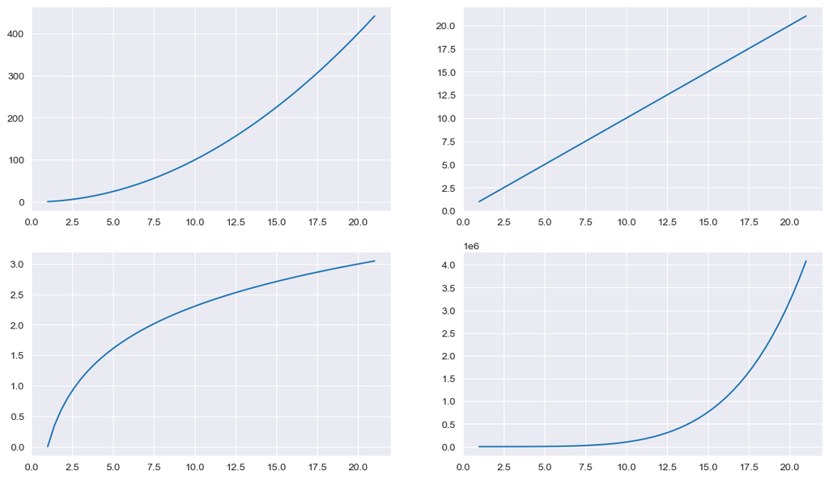

```python
x = np.linspace(1, 21)

fig, axes = plt.subplots(nrows=2, ncols=2, figsize=(14, 8))

axes[0][0].plot(x, x**2)
axes[0][1].plot(x, x)
axes[1][0].plot(x, np.log(x))
axes[1][1].plot(x, x**5)

plt.show()
```

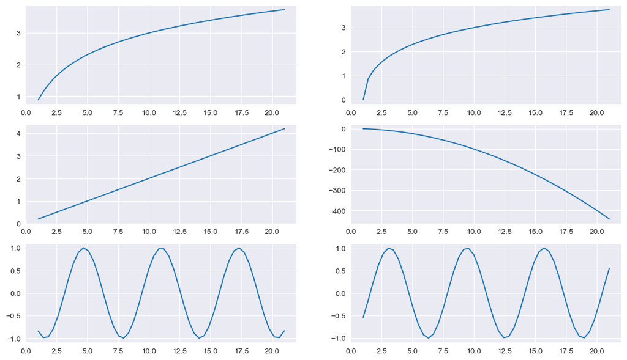

```python
# Modified Work
fig, axes = plt.subplots(nrows=3, ncols=2, figsize=(14, 8))

axes[0][0].plot(x, np.arcsinh(x))
axes[0][1].plot(x, np.arccosh(x))
axes[1][0].plot(x, x/5)
axes[1][1].plot(x, -x**2)
axes[2][0].plot(x, -1*np.sin(x))
axes[2][1].plot(x, -1*np.cos(x))

plt.show()
```

### Custom Axes Range

Something else we'd sometimes like to do is change the x and y axis range. We can configure the ranges of the axes using the `set_ylim` and `set_xlim`, or `axis('tight')` for automatically getting "tightly fitted" axes ranges:

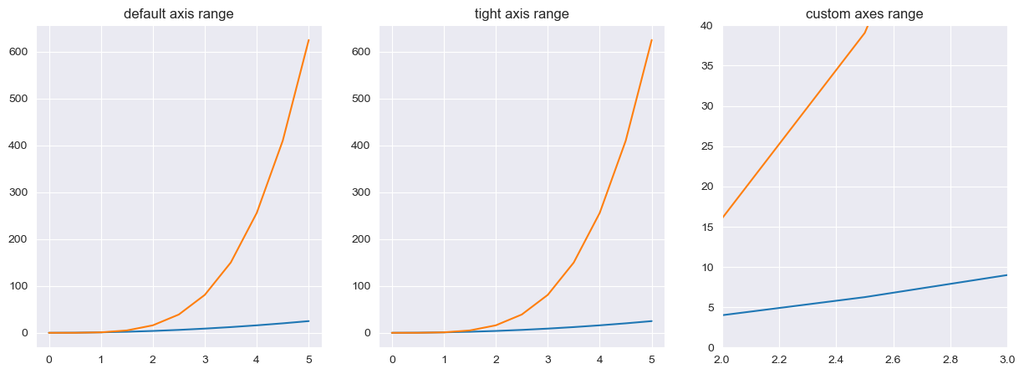

```python
x = np.linspace(0, 5, 11)

fig, axes = plt.subplots(nrows=1, ncols=3)

# we can also plot multiple graphs using plt.plot(x1, y1, x2, y2).
axes[0].plot(x, x**2, x, x**4)
axes[0].set_title('default axis range')

axes[1].plot(x, x**2, x, x**4)
# tight happens to be the same here, but this will come in handy when you want to automatically align axes in a
# fitted manner.
axes[1].axis('tight')
axes[1].set_title('tight axis range')

# notice the zoom in that happened.
axes[2].plot(x, x**2, x, x**4)
axes[2].set_ylim([0, 40])
axes[2].set_xlim([2, 3])
axes[2].set_title("custom axes range")

plt.show()
```

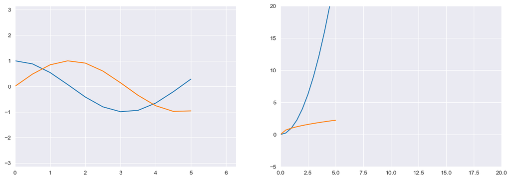

```python
# Modified Work
fig, axes = plt.subplots(nrows=1, ncols=2)

axes[0].plot(x, np.cos(x), x, np.sin(x))
axes[0].set_ylim([-1*np.pi, np.pi])
axes[0].set_xlim([0, 2*np.pi])

axes[1].plot(x, x**2, x, np.sqrt(x))
axes[1].set_ylim([-5, 20])
axes[1].set_xlim([0, 20])

plt.show()
```

*Final Note: The plt.plot() function supports additional arguments that can be used to specify a wide variety of line color and style alternatives. Here are just a few examples, but please refer to the official documentation if you'd like to learn more.*

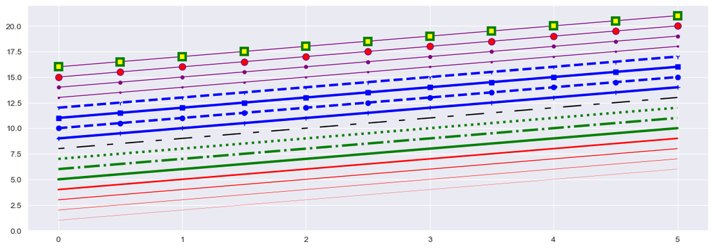

```python
x = np.linspace(0, 5, 11)

plt.plot(x, x+1, color="red", linewidth=0.25)
plt.plot(x, x+2, color="red", linewidth=0.50)
plt.plot(x, x+3, color="red", linewidth=1.00)
plt.plot(x, x+4, color="red", linewidth=2.00)

# possible linestype options ‘-‘, ‘–’, ‘-.’, ‘:’, ‘steps’
plt.plot(x, x+5, color="green", lw=3, linestyle='-')
plt.plot(x, x+6, color="green", lw=3, ls='-.')
plt.plot(x, x+7, color="green", lw=3, ls=':')

# custom dash (not something we'll do often)
line, = plt.plot(x, x+8, color="black", lw=1.50)
line.set_dashes([5, 10, 15, 10]) # format: line length, space length, ...

# possible marker symbols: marker = '+', 'o', '*', 's', ',', '.', '1', '2', '3', '4', ...
plt.plot(x, x+ 9, color="blue", lw=3, ls='-', marker='+')
plt.plot(x, x+10, color="blue", lw=3, ls='--', marker='o')
plt.plot(x, x+11, color="blue", lw=3, ls='-', marker='s')
plt.plot(x, x+12, color="blue", lw=3, ls='--', marker='1')

# marker size and color
plt.plot(x, x+13, color="purple", lw=1, ls='-', marker='o', markersize=2)
plt.plot(x, x+14, color="purple", lw=1, ls='-', marker='o', markersize=4)
plt.plot(x, x+15, color="purple", lw=1, ls='-', marker='o', markersize=8, markerfacecolor="red")
plt.plot(x, x+16, color="purple", lw=1, ls='-', marker='s', markersize=8, markerfacecolor="yellow", markeredgewidth=3, markeredgecolor="green")
```

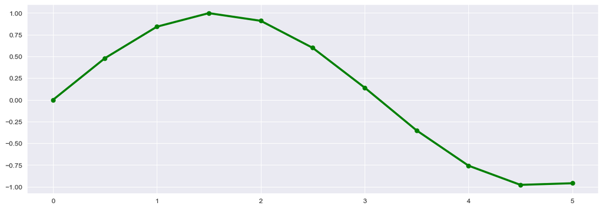

```python
# Modified Work
plt.plot(x, np.sin(x), color="green", lw=3, linestyle='-', marker='o')
```

### Plotting Pandas Columns

Great job! Let's now see how we can plot pandas columns (which essentially behave like arrays), which is much more common and what you'll be doing when exploring your datasets. To do this, let's revisit that pokemon dataset. Plese refer back to the pandas lab if you don't recall the pokemon dataset or need help accessing it.

```python
pokemon_df = pd.read_csv(filepath_or_buffer='Pokemon.csv')
pokemon_df.head()
```

|  | # | Name | Type 1 | Type 2 | Total | HP | Attack | Defense | Sp. Atk | Sp. Def | Speed | Generation | Legendary |
| --- | --- | --- | --- | --- | --- | --- | --- | --- | --- | --- | --- | --- | --- |
| 0 | 1 | Bulbasaur | Grass | Poison | 318 | 45 | 49 | 49 | 65 | 65 | 45 | 1 | False |
| 1 | 2 | Ivysaur | Grass | Poison | 405 | 60 | 62 | 63 | 80 | 80 | 60 | 1 | False |
| 2 | 3 | Venusaur | Grass | Poison | 525 | 80 | 82 | 83 | 100 | 100 | 80 | 1 | False |
| 3 | 3 | VenusaurMega Venusaur | Grass | Poison | 625 | 80 | 100 | 123 | 122 | 120 | 80 | 1 | False |
| 4 | 4 | Charmander | Fire | NaN | 309 | 39 | 52 | 43 | 60 | 50 | 65 | 1 | False |

```python
# Modified Work
pokemon_df.tail()
```

|  | # | Name | Type 1 | Type 2 | Total | HP | Attack | Defense | Sp. Atk | Sp. Def | Speed | Generation | Legendary |
| --- | --- | --- | --- | --- | --- | --- | --- | --- | --- | --- | --- | --- | --- |
| 795 | 719 | Diancie | Rock | Fairy | 600 | 50 | 100 | 150 | 100 | 150 | 50 | 6 | True |
| 796 | 719 | DiancieMega Diancie | Rock | Fairy | 700 | 50 | 160 | 110 | 160 | 110 | 110 | 6 | True |
| 797 | 720 | HoopaHoopa Confined | Psychic | Ghost | 600 | 80 | 110 | 60 | 150 | 130 | 70 | 6 | True |
| 798 | 720 | HoopaHoopa Unbound | Psychic | Dark | 680 | 80 | 160 | 60 | 170 | 130 | 80 | 6 | True |
| 799 | 721 | Volcanion | Fire | Water | 600 | 80 | 110 | 120 | 130 | 90 | 70 | 6 | True |

matplotlib has a wide variety of plot types. We've only seen simple line plots above, but let's see how we can create a scatter plot of pokemon HP and Attack. We can acomplish this using `plt.scatter(x, y)`, where x and y can be arrays (as we saw earlier), or pandas columns.

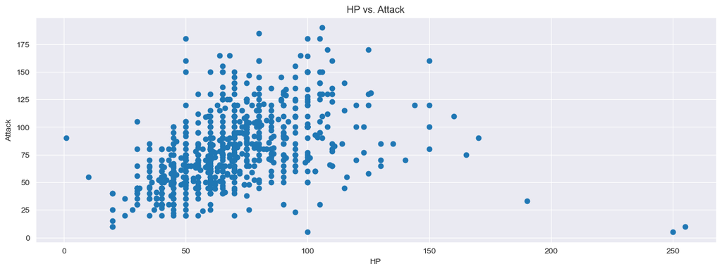

```python
plt.scatter(x=pokemon_df['HP'], y=pokemon_df['Attack'])
plt.xlabel('HP')
plt.ylabel('Attack')
plt.title('HP vs. Attack')
plt.show()
```

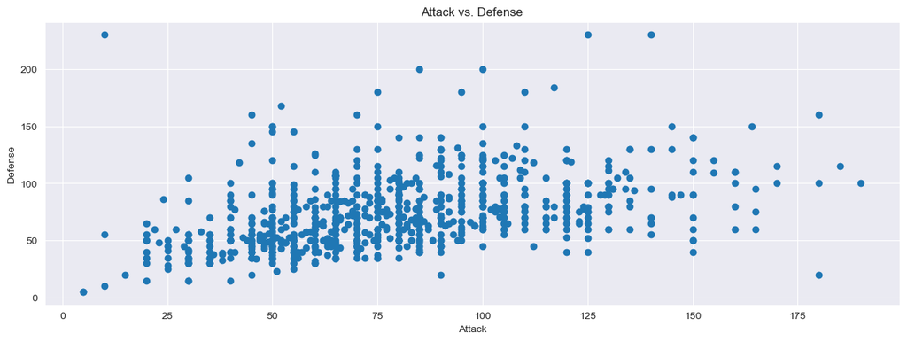

```python
# Modified Work
plt.scatter(x=pokemon_df['Attack'], y=pokemon_df['Defense'])
plt.xlabel('Attack')
plt.ylabel('Defense')
plt.title('Attack vs. Defense')
plt.show()
```

Optional plot: If you've installed seaborn and imported it, we can easily expand on the scatterplot above by plotting each point by a specific category (Generation in this case). To do this, we simply specify the category we'd like to color by in an additional hue parameter. This can also be achieved in matplotlib, but you have to create a dictionary and map each unique value to a color, which can be a bit tedious.

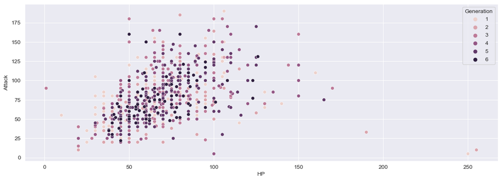

```python
sns.scatterplot(x=pokemon_df['HP'], y=pokemon_df['Attack'], hue='Generation', data=pokemon_df)
plt.show()
```

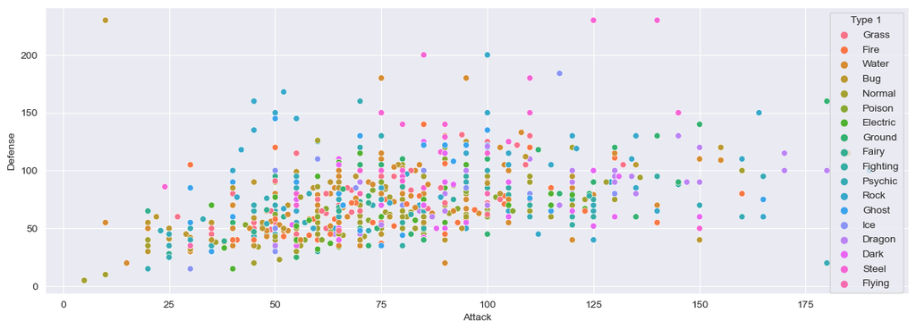

```python
# Modified Work
sns.scatterplot(x=pokemon_df['Attack'], y=pokemon_df['Defense'], hue='Type 1', data=pokemon_df)
plt.show()
```

We can visualize the distribution of any pandas column using `plt.hist(x)`, where x is any pandas column.

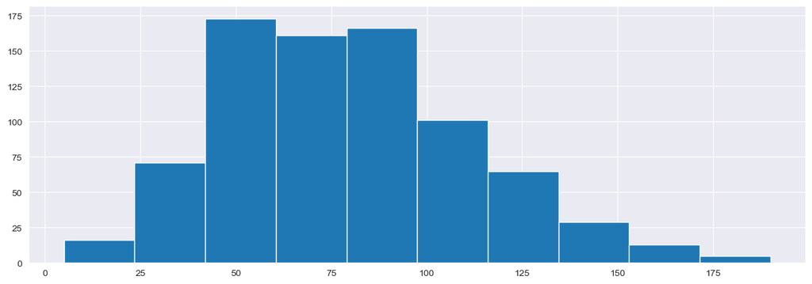

```python
plt.hist(x=pokemon_df['Attack'])
plt.show()
```

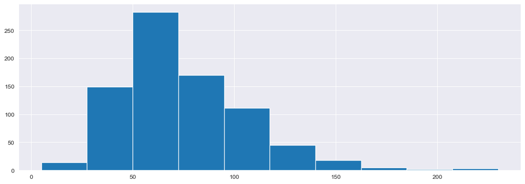

```python
# Modified Work
plt.hist(x=pokemon_df['Defense'])
plt.show()
```

Let's see a few plots that require us to do a little more work to create. I say a little more work because it may require us to gather multiple information in some cases.

Recall what `.value_counts()` from the pandas section gave us. Calling `value_counts()` on pokemon_df['Type 1'] will list out each unique Type 1 pokemon type and how many pokemon of that type are in our dataset. However, this information looks rather boring. Let's see how we can turn this info into a bar plot.

```python
pokemon_df['Type 1'].value_counts()
```

```
Type 1
Water       112
Normal       98
Grass        70
Bug          69
Psychic      57
Fire         52
Electric     44
Rock         44
Dragon       32
Ground       32
Ghost        32
Dark         31
Poison       28
Steel        27
Fighting     27
Ice          24
Fairy        17
Flying        4
Name: count, dtype: int64
```

```python
# Modified Work
pokemon_df['Type 2'].value_counts()
```

```
Type 2
Flying      97
Ground      35
Poison      34
Psychic     33
Fighting    26
Grass       25
Fairy       23
Steel       22
Dark        20
Dragon      18
Water       14
Ghost       14
Ice         14
Rock        14
Fire        12
Electric     6
Normal       4
Bug          3
Name: count, dtype: int64
```

Calling `.index` off of `.value_counts()` will return just the index names. Calling `.values` off of `.value_counts()` will return just the corresponding values. What we'll do is save this information into variables and then use these variables as our x and y in `plt.bar(x, y)` to create our bar plot. Notice how x is the index labels, and y is the corresponding value counts in the plot below.

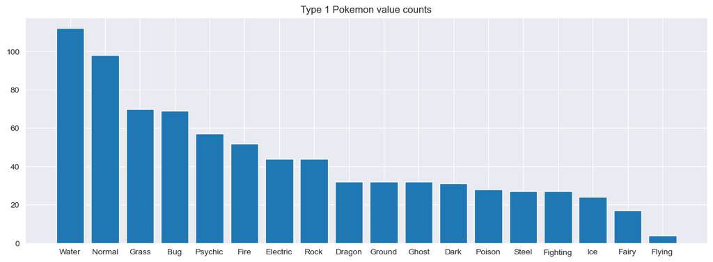

```python
# collect index names (left side of .value_counts())
type_1_names = pokemon_df['Type 1'].value_counts().index
# collect corresponding value counts (right side of .value_counts())
type_1_values = pokemon_df['Type 1'].value_counts().values
# plt.bar(x, y)
plt.bar(type_1_names, type_1_values)
plt.title('Type 1 Pokemon value counts')
plt.show()
```

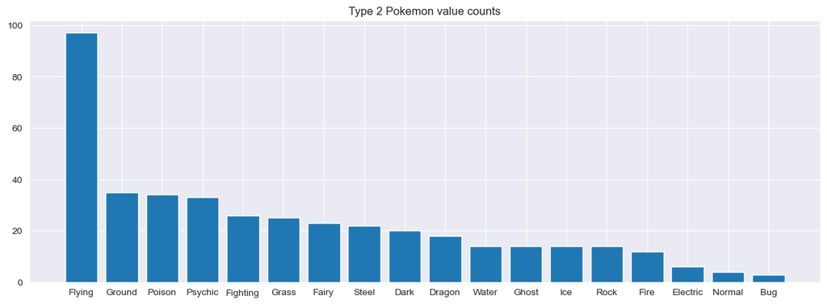

```python
# Modified Work
type_2_x = pokemon_df['Type 2'].value_counts().index
type2_y = pokemon_df['Type 2'].value_counts().values

plt.bar(type_2_x, type2_y)
plt.title('Type 2 Pokemon value counts')
plt.show()
```

We can also take the top 5 types above (Water, Normal, Grass, Bug, Psychic) and represent this information in a pie chart using `plt.pie(sizes, colors)`. Sizes is the size for each wegde in the pie chart. For sizes we'll pass only the first 5 type_1_values. We'll also pass a colors array to give each wedge a unique color. Shadow=True is optional (just adds a slight shadow to our pie chart for visual purposes), and startangle=90 is the angle by which the start of the pie is rotated, counterclockwise from the x-axis.

Note that `plt.pie(sizes, colors)` returns two things. patches, which is a sequence of matplotlib.patches.Wedge instances, and texts, a list of the label Text instances. It's important that we save these into variables so that we can pass this information to `plt.legend(patches, names)`. We'll pass patches so that the legend knows which patch/wedge corresponds to which color, and the first 5 type_1_names as the corresponding name to each patch/wedge.

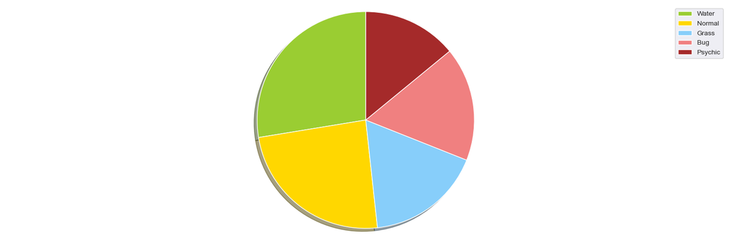

```python
# colors we'll use for each patch/wedge
colors = ['yellowgreen', 'gold', 'lightskyblue', 'lightcoral','brown']
patches, texts = plt.pie(type_1_values[:5], colors=colors, shadow=True, startangle=90)
plt.legend(patches, type_1_names[:5])
# will center our pie chart, but not necessary
plt.axis('equal')
plt.tight_layout()
plt.show()
```

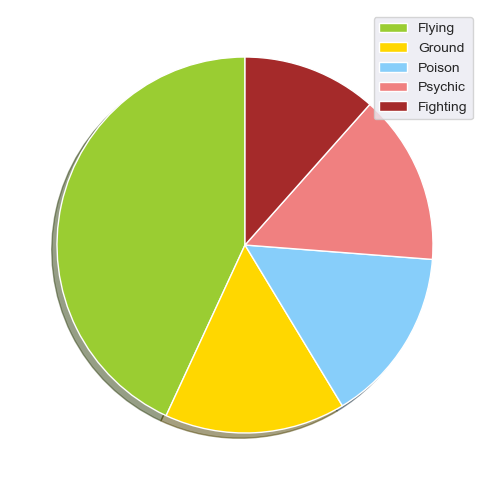

```python
# Modified Work

patches, texts = plt.pie(type2_y[:5], colors=colors, shadow=True, startangle=90)
plt.legend(patches, type_2_x[:5])

# plt.axis('equal')
plt.tight_layout()
plt.show()
```

Let's collect the first 4 pokemon names in our DataFrame along with their corresponding HP, Attack, and defense.

```python
x = pokemon_df['Name'][:4]
y1 = pokemon_df['HP'][:4]
y2 = pokemon_df['Attack'][:4]
y3 = pokemon_df['Defense'][:4]
```

```python
# Modified Work

rx = pokemon_df['Name'].sample(n=5, random_state=5)
ry1 = pokemon_df['HP'].sample(n=5, random_state=5)
ry2 = pokemon_df['Attack'].sample(n=5, random_state=5)
ry3 = pokemon_df['Defense'].sample(n=5, random_state=5)
```

We can compare these 4 pokemon using a stackplot. `plt.stackplot(x, y1, y2, y3)` works as follows in our case: x is the first 4 pokemon in our dataset, y1 is their corresponding HPs, y2 their corresponding Attacks, and y3 their corresponding defense values. Notice how we're stacking each attribute on top of each of the 4 pokemon.

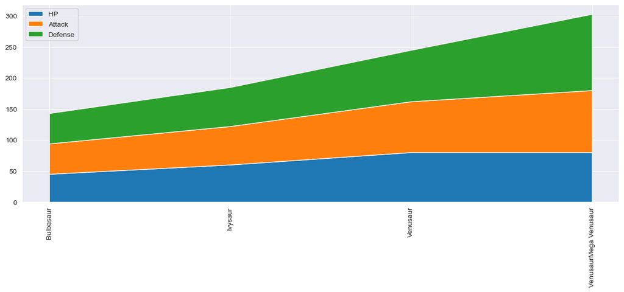

```python
labels = ["HP ", "Attack", "Defense"]

plt.stackplot(x, y1, y2, y3)
plt.legend(loc='upper left', labels=labels)
# rotates the xlabels to appear vertical rather than horizontal by default.
plt.xticks(rotation=90)
plt.show()
```

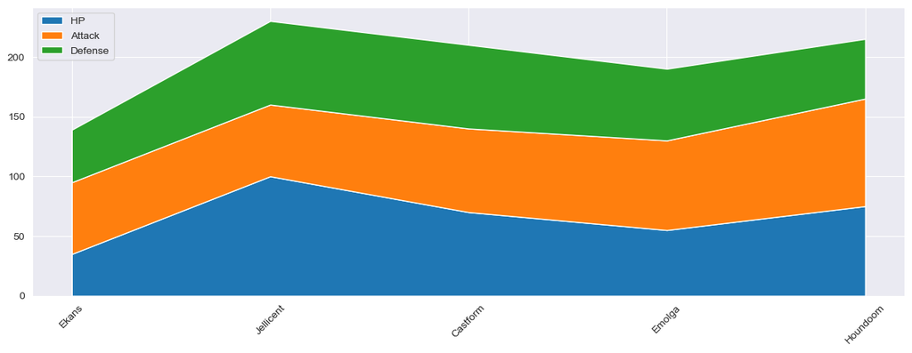

```python
# Modified Work

plt.stackplot(rx, ry1, ry2, ry3)
plt.legend(loc='upper left', labels=labels)
plt.xticks(rotation=45)
plt.show()
```

We can also use our knowledge of subplots to represent this information in 3 separate subplots if we'd like. Recall that x is the first 4 pokemon names in our dataset (Bulbasaur, Ivysaur, Venusaur, VenusaurMega Venusaur). So for each of these 3 subplots we're plotting the names along the x axis, and their corresponding HP or Attack or Defense value as the y value.

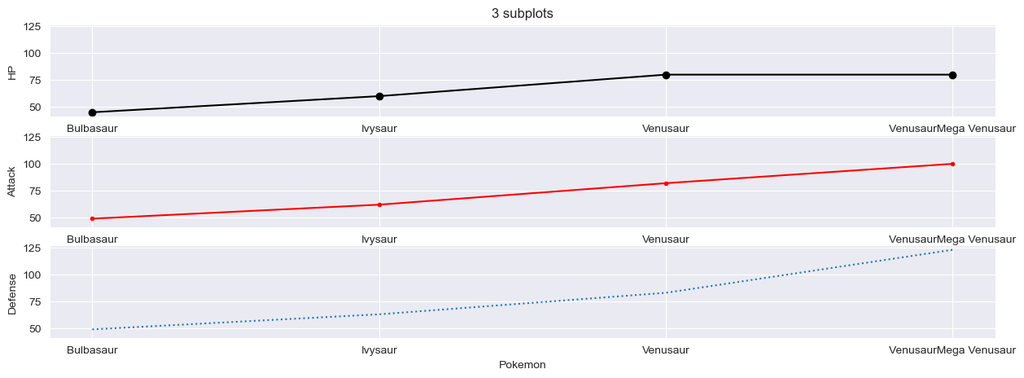

```python
# Create 3 subplots sharing y axis
fig, axes = plt.subplots(nrows=3, ncols=1, sharey=True)

# 'ko-, r.-, and : are just line styles and optional.'
# notice how you can also set multiple things together in one single command rather than
# creating separate .set_title, .set_ylabel, .set_xlabel, etc. commands like we were doing earlier.
axes[0].plot(x, y1, 'ko-')
axes[0].set(title='3 subplots', ylabel='HP')

axes[1].plot(x, y2, 'r.-')
axes[1].set(xlabel='Pokemon', ylabel='Attack')

axes[2].plot(x, y3, ':')
axes[2].set(xlabel='Pokemon', ylabel='Defense')

plt.show()
```

[figure not shown]

```python
# Modified Work
fig, axes = plt.subplots(nrows=3, ncols=1, sharey=True)

axes[0].plot(rx, ry1, 'ko-')
axes[0].set(title='3 subplots', ylabel='HP')

axes[1].plot(rx, ry2, 'r.-')
axes[1].set(xlabel='Pokemon', ylabel='Attack')

axes[2].plot(rx, ry3, ':')
axes[2].set(xlabel='Pokemon', ylabel='Defense')

plt.show()
```

We can also make line plots of pandas columns, which we've seen in the earlier lab sections when we were passing arrays. These type of plots will come in handy if you decide to work with stock data for your project.

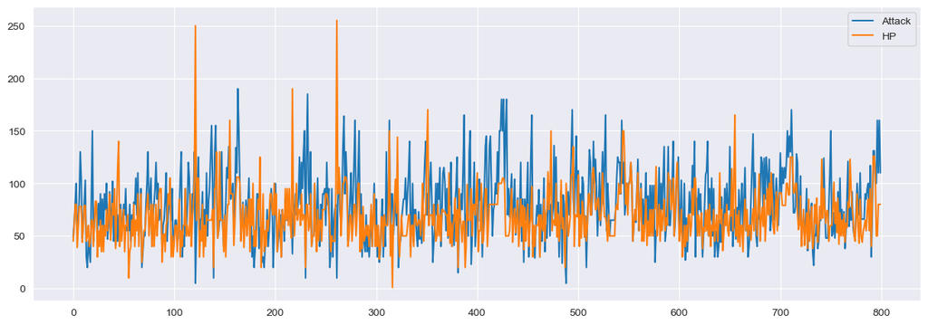

```python
plt.plot(pokemon_df['Attack'], label='Attack')
plt.plot(pokemon_df['HP'], label='HP')
plt.legend()
plt.show()
```

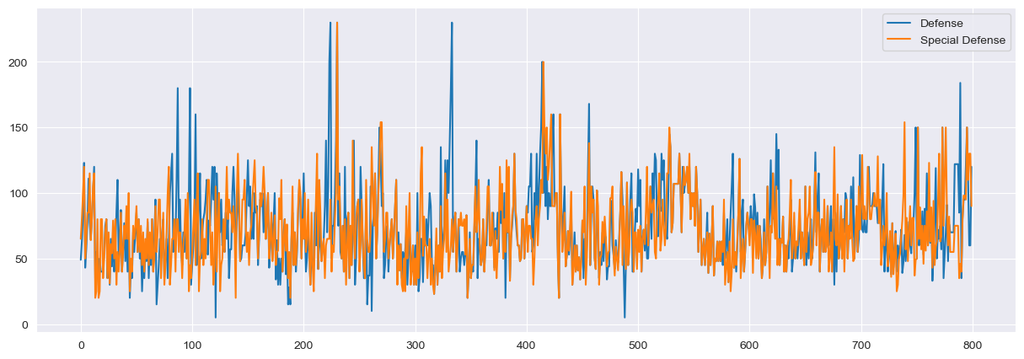

```python
# Modified Work
plt.plot(pokemon_df['Defense'], label='Defense')
plt.plot(pokemon_df['Sp. Def'], label='Special Defense')
plt.legend()
plt.show()
```

One last and very important plot that we'll talk about is the heatmap. If we call `.corr()` on a DataFrame we'll get back a correlation matrix.

*Note: Make sure you don't have categorical variables in your DataFrame or you'll get an error.*

```python
pokemon_df[['HP', 'Attack', 'Defense','Sp. Atk', 'Sp. Def', 'Speed']].corr()
```

|  | HP | Attack | Defense | Sp. Atk | Sp. Def | Speed |
| --- | --- | --- | --- | --- | --- | --- |
| HP | 1.000000 | 0.422386 | 0.239622 | 0.362380 | 0.378718 | 0.175952 |
| Attack | 0.422386 | 1.000000 | 0.438687 | 0.396362 | 0.263990 | 0.381240 |
| Defense | 0.239622 | 0.438687 | 1.000000 | 0.223549 | 0.510747 | 0.015227 |
| Sp. Atk | 0.362380 | 0.396362 | 0.223549 | 1.000000 | 0.506121 | 0.473018 |
| Sp. Def | 0.378718 | 0.263990 | 0.510747 | 0.506121 | 1.000000 | 0.259133 |
| Speed | 0.175952 | 0.381240 | 0.015227 | 0.473018 | 0.259133 | 1.000000 |

```python
# Modified Work
pokemon_df[['Attack', 'Defense','Sp. Atk', 'Sp. Def']].corr()
```

|  | Attack | Defense | Sp. Atk | Sp. Def |
| --- | --- | --- | --- | --- |
| Attack | 1.000000 | 0.438687 | 0.396362 | 0.263990 |
| Defense | 0.438687 | 1.000000 | 0.223549 | 0.510747 |
| Sp. Atk | 0.396362 | 0.223549 | 1.000000 | 0.506121 |
| Sp. Def | 0.263990 | 0.510747 | 0.506121 | 1.000000 |

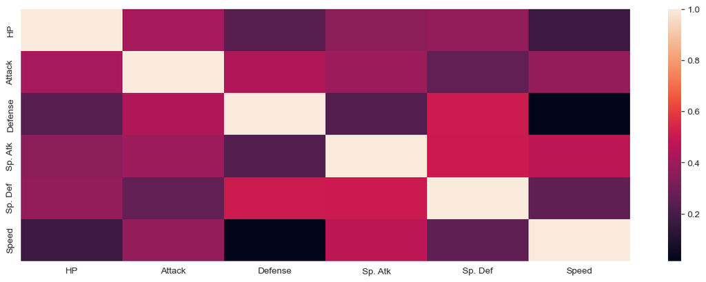

```python
sns.heatmap(pokemon_df[['HP', 'Attack', 'Defense','Sp. Atk', 'Sp. Def', 'Speed']].corr())
plt.show()
```

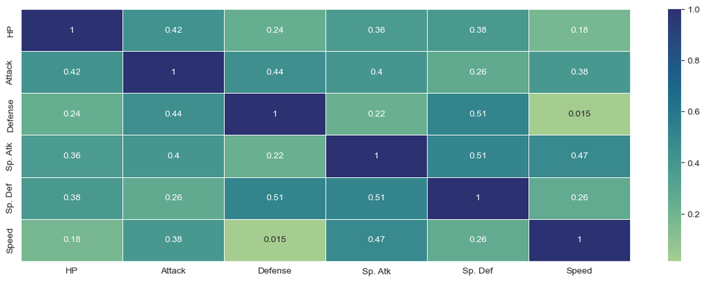

```python
# Modified Work
corr_matrix = pokemon_df[['HP', 'Attack', 'Defense','Sp. Atk', 'Sp. Def', 'Speed']].corr()
sns.heatmap(corr_matrix, annot=True, linewidth=.5, cmap="crest")
plt.show()
```

Note: You can also use matplotlib for this, but it's much more intuitive in Seaborn and just one line of code, so I'd really recommend at least using Seaborn for heatmaps. You'll usually see people mixing a combination of matplotlib and Seaborn since it's a really powerful combo. Since Seaborn is built on matplotlib, a lot of plots can be made with just one or 2 lines of code in Seaborn and then you can just use matplotlib to tweek certain things to your liking that are hidden in Seaborn (hidden for simplicity and easy use).

Congrats! 🙂 You now know enough to begin exploring and visualizing data on your own. As always, feel free to continue exploring this dataset or repeat some of the steps above on a new dataset as practice. Also refer back to the [documentation](https://matplotlib.org/stable/gallery/index.html) if we didn't get to cover a graph you need for your project this semester. Most visualization tools and libraries support just about every statistical plots you can think of.